# DATA 624 | Predictive Analytics

```r
#eda
#lamb_dcmp = nsw_lamb %>%
#  model(stl = STL(Count))

#components(lamb_dcmp) %>% autoplot()
```

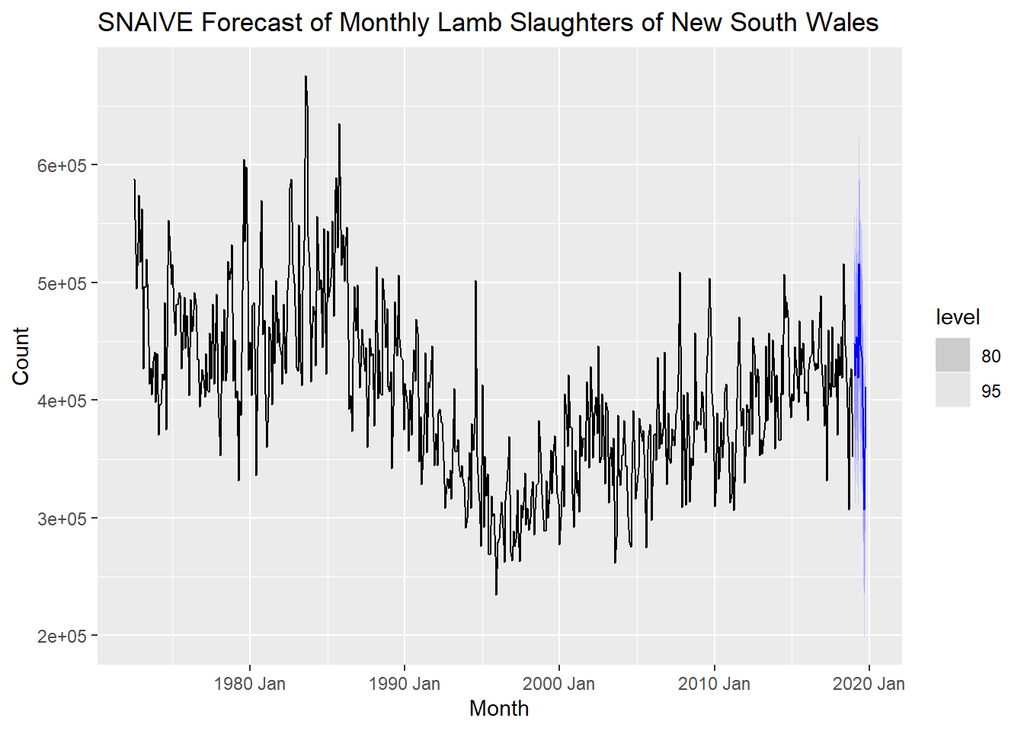

```r
#Select and train the model
lambs_fit <- nsw_lamb %>%
  model( snaive = SNAIVE(Count ~ lag("year") ) )

#forecast
fc_lambs =lambs_fit %>% forecast(h=10)

fc_lambs %>%
  autoplot(nsw_lamb)+
  labs(title= "SNAIVE Forecast of Monthly Lamb Slaughters of New South Wales")
```

**Household wealth** (`hh_budget`)

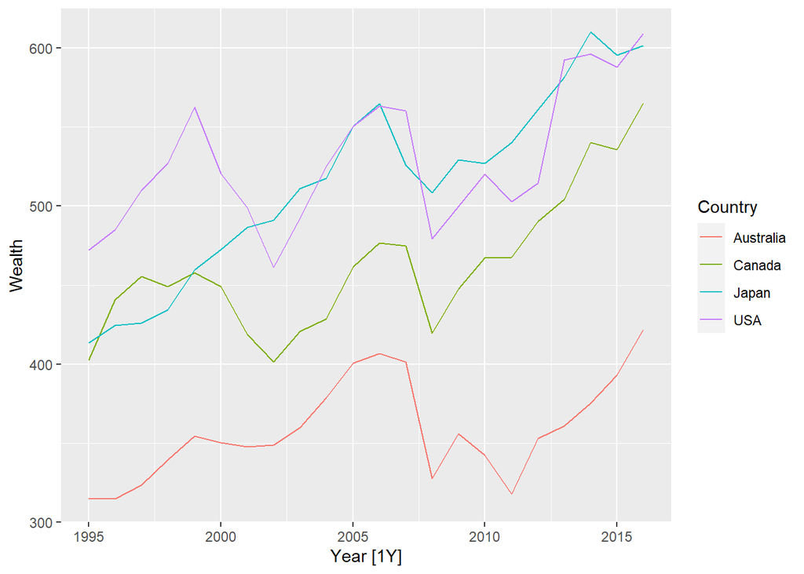

```r
#help("hh_budget")

hh_budget %>%
  autoplot(Wealth)
```

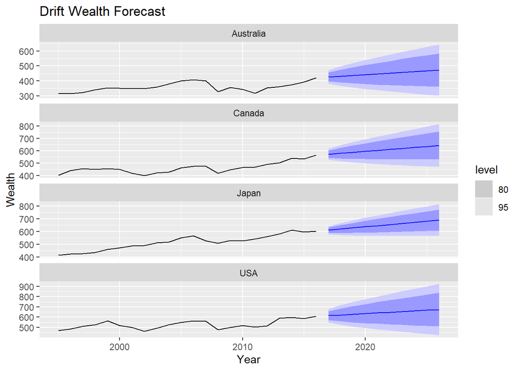

```r
hh_model = hh_budget %>%
  model(`RW` = RW(Wealth ~ drift()))
  #model( naive = NAIVE(Wealth ) )


fc_wealth = hh_model %>%
  forecast(h = 10)

fc_wealth %>% autoplot(hh_budget) +
  labs(title="Drift Wealth Forecast",
       ylab="% of net disposable income")
```

Initially I thought it would be better to do a `NAIVE(y)` on the data given it is financial in nature, however it seems only provide a straight stagnant line; as such a `RW(y ~ drift())` was also run and seems to provide a slight upward forecast that in in line with the previous years for all countries in the data set.

**Australian takeaway food turnover** (`aus_retail`)

```r
takeaway = aus_retail %>% filter( Industry == 'Takeaway food services', State == "Australian Capital Territory") %>%
  select(State, Industry, Month, Turnover)
head(takeaway)
```

```
## # A tsibble: 6 x 4 [1M]
## # Key:       State, Industry [1]
##   State                        Industry                  Month Turnover
##   <chr>                        <chr>                     <mth>    <dbl>
## 1 Australian Capital Territory Takeaway food services 1982 Apr      3.2
## 2 Australian Capital Territory Takeaway food services 1982 May      3.3
## 3 Australian Capital Territory Takeaway food services 1982 Jun      3.5
## 4 Australian Capital Territory Takeaway food services 1982 Jul      3.5
## 5 Australian Capital Territory Takeaway food services 1982 Aug      3.7
## 6 Australian Capital Territory Takeaway food services 1982 Sep      3.9
```

```
## Plot variable not specified, automatically selected `.vars = Turnover`
```

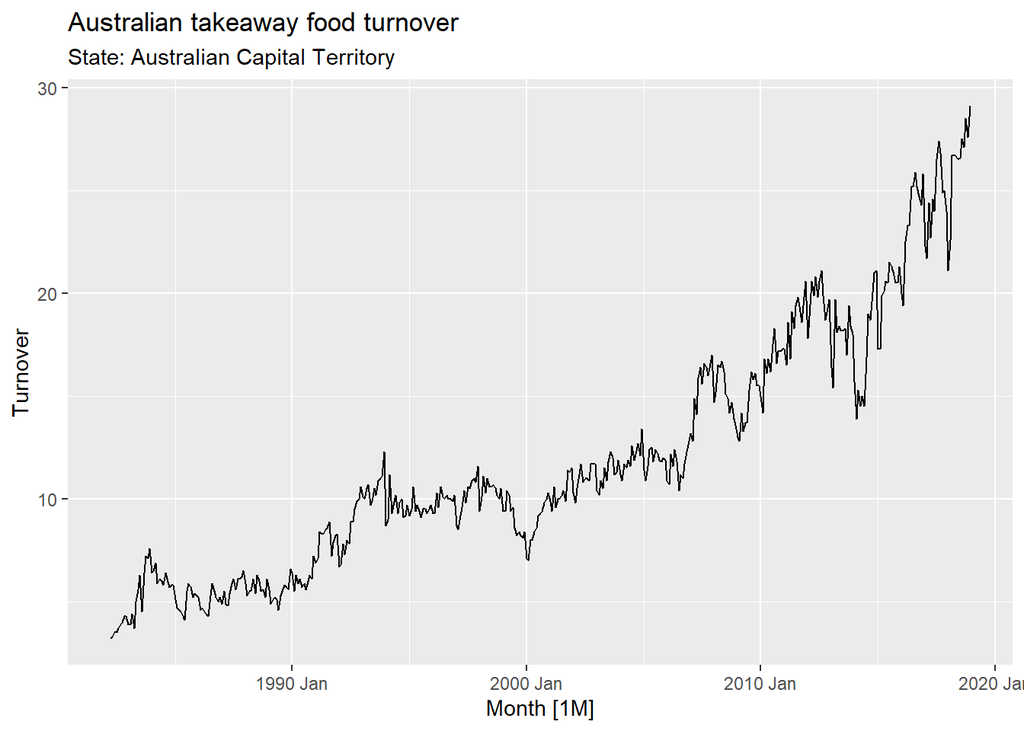

```r
autoplot(takeaway, show.legend = FALSE)+
  labs(title= "Australian takeaway food turnover",
       subtitle = "State: Australian Capital Territory")
```

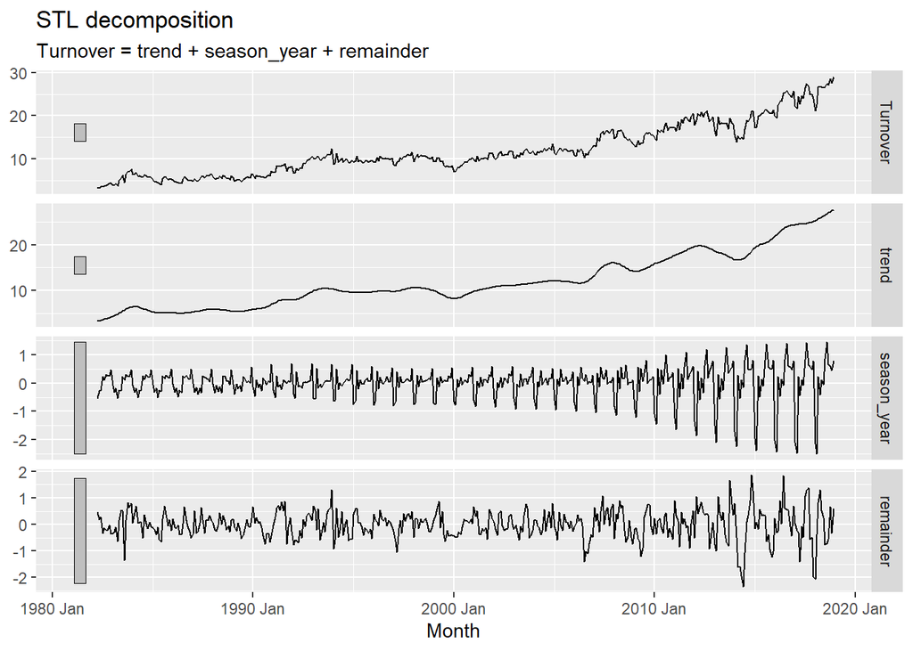

```r
#eda
tkout_dcmp = takeaway %>%
  model(stl = STL(Turnover))

components(tkout_dcmp) %>% autoplot(show.legend = FALSE)
```

Based on the STL decomposition and the seasonality displayed, the `SNAIVE(y)` method was used.

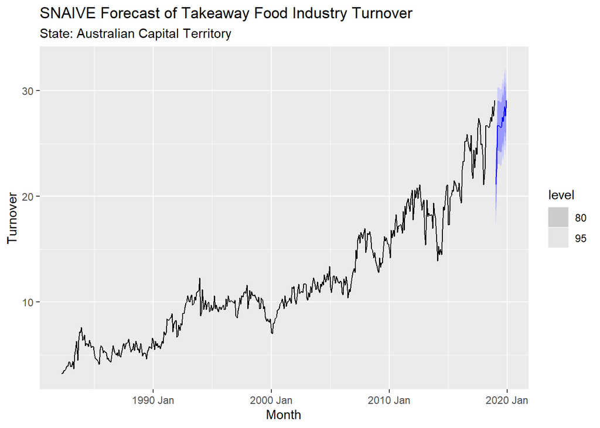

```r
#Select and train the model
tkway_fit <- takeaway %>%
  model(SNAIVE(Turnover ~ lag("year")))

#Produce forecast
tkway_fc <- tkway_fit %>% forecast(h = 12)

#filter and plot
tkway_fc %>% filter(State=='Australian Capital Territory') %>%
     autoplot(takeaway)+
  labs(title= "SNAIVE Forecast of Takeaway Food Industry Turnover",
    subtitle= "State: Australian Capital Territory")
```

### 5.2

Use the Facebook stock price (data set `gafa_stock`) to do the following:

1. Produce a time plot of the series.
2. Produce forecasts using the drift method and plot them.
3. Show that the forecasts are identical to extending the line drawn between the first and last observations.
4. Try using some of the other benchmark functions to forecast the same data set. Which do you think is best? Why?

**Produce a time plot of the series**

```r
#unique(gafa_stock$Symbol)
# Re-index based on trading days
fb_stock <- gafa_stock %>%
  filter(Symbol == "FB")%>%
  mutate(day = row_number()) %>%
  update_tsibble(index = day, regular = TRUE)

#check the ! is now a 1 for daily adjustment
head(fb_stock,2)
```

```
## # A tsibble: 2 x 9 [1]
## # Key:       Symbol [1]
##   Symbol Date        Open  High   Low Close Adj_Close   Volume   day
##   <chr>  <date>     <dbl> <dbl> <dbl> <dbl>     <dbl>    <dbl> <int>
## 1 FB     2014-01-02  54.8  55.2  54.2  54.7      54.7 43195500     1
## 2 FB     2014-01-03  55.0  55.7  54.5  54.6      54.6 38246200     2
```

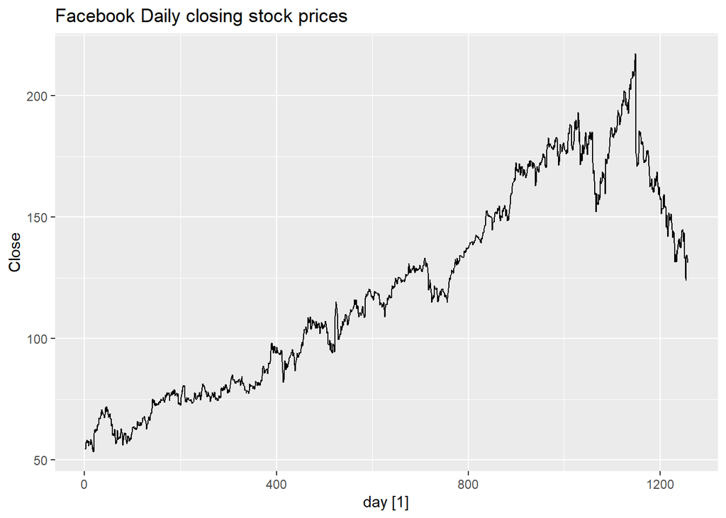

```r
#plot
fb_stock %>% autoplot(Close)+
  labs(title= "Facebook Daily closing stock prices")
```

**Produce forecasts using the drift method and plot them**

Using the [Example: fb’s daily closing stock price](https://otexts.com/fpp3/simple-methods.html#example-fbs-daily-closing-stock-price) of chapter 5.2:

```r
# Filter the year of interest
fb_2015 <- fb_stock %>% filter(year(Date) == 2015)
# Fit the models
fb_fit <- fb_2015 %>%
  model(
    `Naïve Drift` = NAIVE(Close~drift()),
    `RW Drift` = RW(Close ~ drift())
  )
# Produce forecasts for the trading days in January 2016
fb_jan_2016 <- fb_stock %>%
  filter(yearmonth(Date) == yearmonth("2016 Jan"))
fb_fc <- fb_fit %>%
  forecast(new_data = fb_jan_2016)
```

**Show that the forecasts are identical to extending the line drawn between the first and last observations**

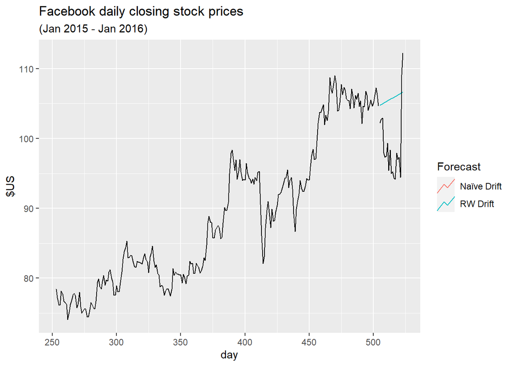

```r
# Plot the forecasts
fb_fc %>%
  autoplot(fb_2015, level = NULL) +
  autolayer(fb_jan_2016, Close, colour = "black") +
  labs(y = "$US",
       title = "Facebook daily closing stock prices",
       subtitle = "(Jan 2015 - Jan 2016)") +
  guides(colour = guide_legend(title = "Forecast"))
```

**Try using some of the other benchmark functions to forecast the same data set. Which do you think is best? Why?**

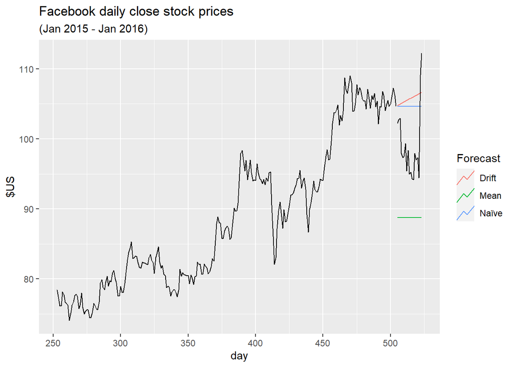

```r
#Fit the models
fb_fit2 <- fb_2015 %>%
  model(
    Mean = MEAN(Close),
    `Naïve` = NAIVE(Close),
    Drift = NAIVE(Close ~ drift())
  )

#Produce forecasts for January 2016
fb_fc2 <- fb_fit2 %>%
  forecast(new_data = fb_jan_2016)

#Re-plot forecasts vs. actual
fb_fc2 %>%
  autoplot(fb_2015, level = NULL) +
  autolayer(fb_jan_2016, Close, colour = "black") +
  labs(y = "$US",
       title = "Facebook daily close stock prices",
       subtitle = "(Jan 2015 - Jan 2016)") +
  guides(colour = guide_legend(title = "Forecast"))
```

The best of the three benchmarks shown above would be the Drift benchmark as it seems to capture the change between the first point and the last point of the interval, resulting in a line with a postitive slpoe.

### 5.3

Apply a seasonal naïve method to the quarterly Australian beer production data from 1992. Check if the residuals look like white noise, and plot the forecasts. The following code will help.

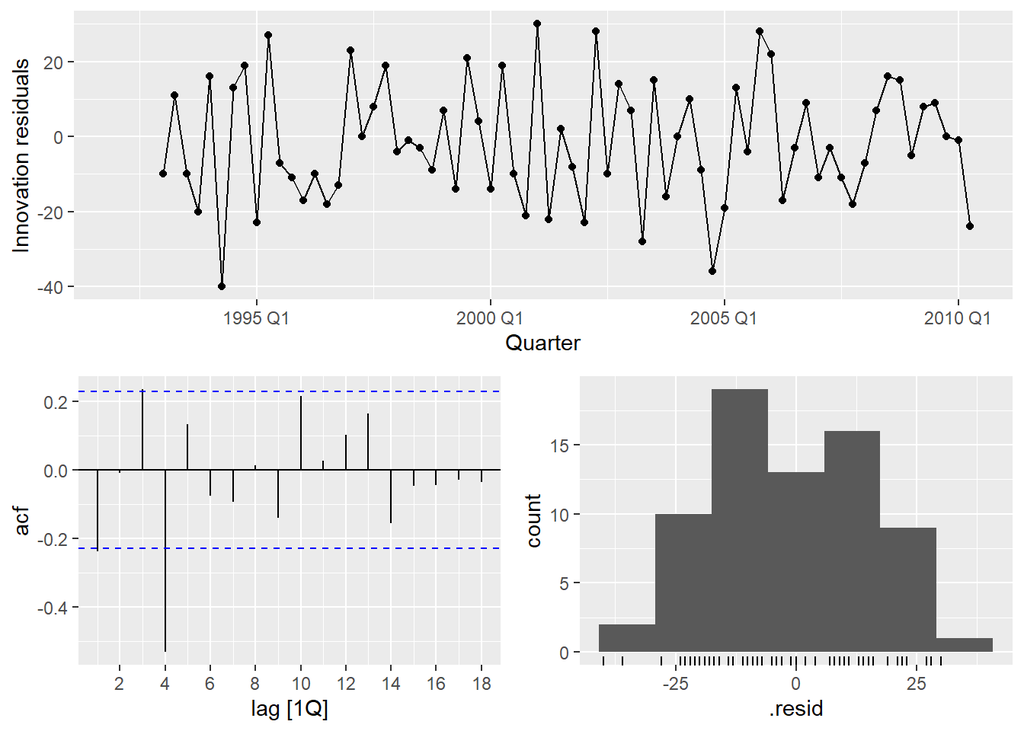

```r
# Extract data of interest
recent_production <- aus_production %>%
  filter(year(Quarter) >= 1992)
# Define and estimate a model
fit <- recent_production %>% model(SNAIVE(Beer))
# Look at the residuals
fit %>% gg_tsresiduals()
```

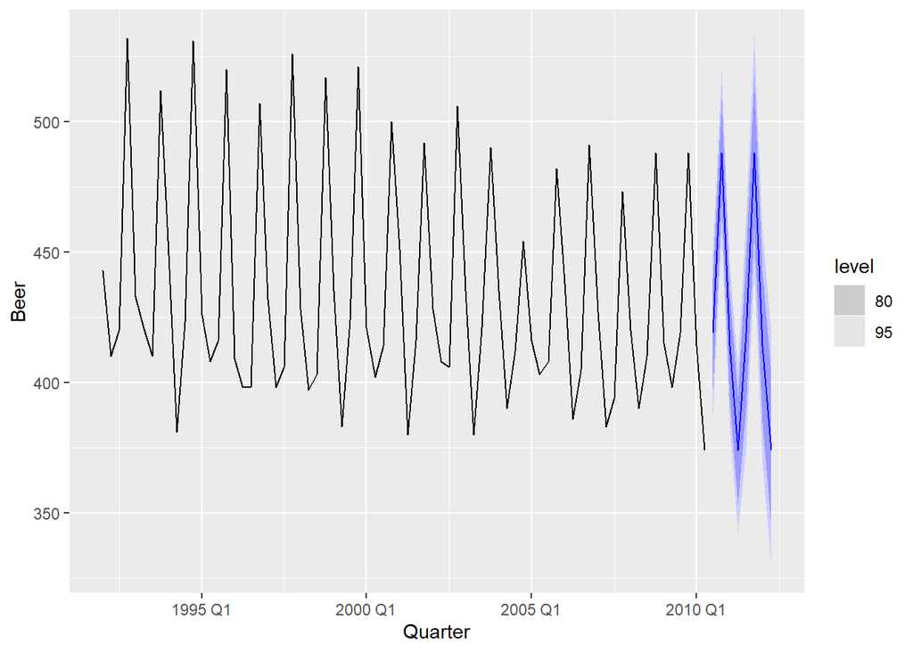

```r
# Look a some forecasts
fit %>% forecast() %>% autoplot(recent_production)
```

What do you conclude?

Based on the plots above, the residuals do not look like white noise [^2]. Looking at the ACF plot, there is one line that is well below the blue dashed line, and another just above the bound, as such it is not considered to be white noise.

### 5.4

Repeat the previous exercise using the Australian Exports series from `global_economy` and the Bricks series from `aus_production`. Use whichever of `NAIVE()` or `SNAIVE()` is more appropriate in each case.

**Australian Exports**

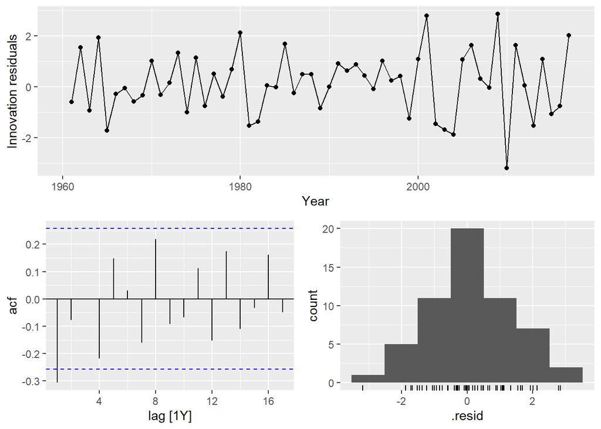

```r
#Filter for training data
aus_pop <- global_economy %>%
    filter(Country == "Australia")
# Define and estimate a model
fit <- aus_pop %>% model(NAIVE(Exports))
# Look at the residuals
fit %>% gg_tsresiduals()
```

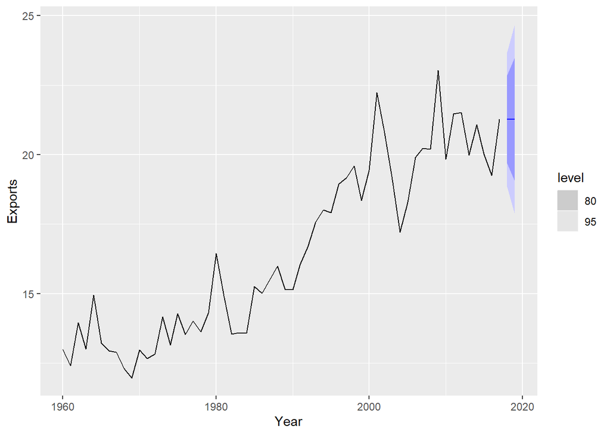

```r
# Look a some forecasts
fit %>% forecast() %>% autoplot(aus_pop)
```

```r
1-(1/16)
```

```
## [1] 0.9375
```

```r
mean(augment(fit)$.innov , na.rm = TRUE)
```

```
## [1] 0.1451912
```

The histogram of the residuals show a normal distribution leading to believe that forecasts from this method will probably be good. Additionally, the mean of the residuals has a mean close to zero meaning that there is little bias in the results.

**Bricks Production**

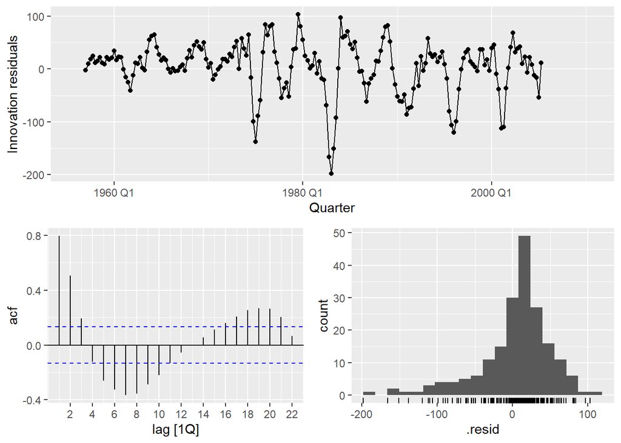

```r
#Filter for training data
aus_bricks <- aus_production %>%
  select(Bricks)
# Define and estimate a model
fit_bricks <- aus_bricks %>% model(SNAIVE(Bricks))
# Look at the residuals
fit_bricks %>% gg_tsresiduals()
```

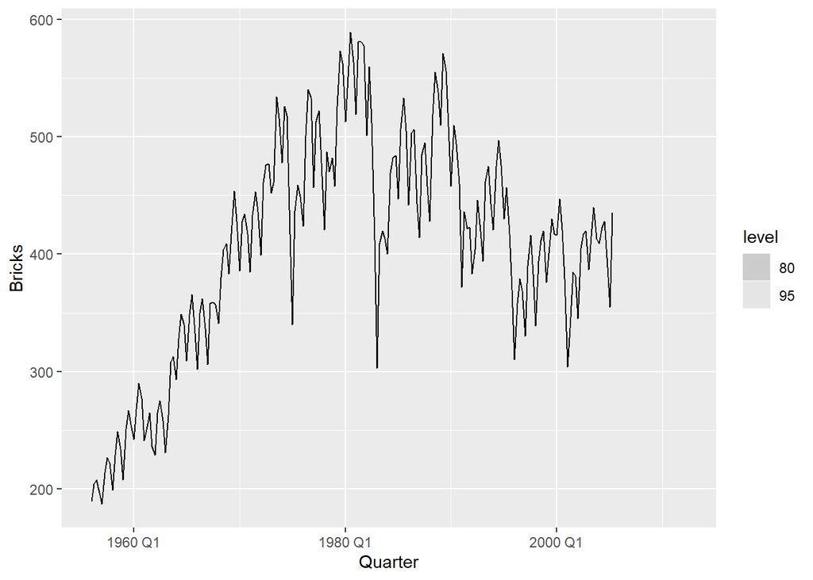

```r
# Look a some forecasts
fit_bricks %>% forecast() %>% autoplot(aus_bricks)
```

```r
mean(augment(fit_bricks)$.innov , na.rm = TRUE)
```

```
## [1] 4.21134
```

Looking at the ACF plot, it looks like there is high autocorrelation in the residual series especially at $r_1$ with a clear seasonal pattern starting at $r_4$. As seen above, we also have a mean of 4.21 which suggests the forecast is biased. Additionally the histogram of the residuals show that they are left-skewed.

### 5.7

For your retail time series (from Exercise 8 in Section 2.10):

```r
set.seed(555)

myseries <- aus_retail %>%
  filter(`Series ID` == sample(aus_retail$`Series ID`,1))

head(myseries)
```

```
## # A tsibble: 6 x 5 [1M]
## # Key:       State, Industry [1]
##   State             Industry          `Series ID`    Month Turnover
##   <chr>             <chr>             <chr>          <mth>    <dbl>
## 1 Western Australia Department stores A3349434X   1982 Apr     36.5
## 2 Western Australia Department stores A3349434X   1982 May     43.7
## 3 Western Australia Department stores A3349434X   1982 Jun     38
## 4 Western Australia Department stores A3349434X   1982 Jul     42
## 5 Western Australia Department stores A3349434X   1982 Aug     38.5
## 6 Western Australia Department stores A3349434X   1982 Sep     40.2
```

1. Create a training dataset consisting of observations before 2011 using:

```r
myseries_train <- myseries %>%
  filter(year(Month) < 2011)
```

2. Check that your data have been split appropriately by producing the following plot.

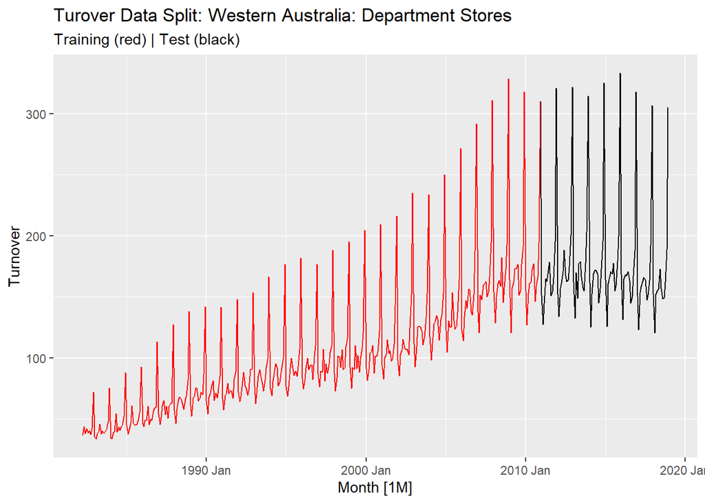

```r
autoplot(myseries, Turnover) +
  autolayer(myseries_train, Turnover, colour = "red")+
  labs(title="Turover Data Split: Western Australia: Department Stores",
       subtitle="Training (red) | Test (black)")
```

3. Fit a seasonal naïve model using `SNAIVE()` applied to your training data (`myseries_train`).

```r
fit <- myseries_train %>%
  model(SNAIVE(Turnover))
```

4. Check the residuals.

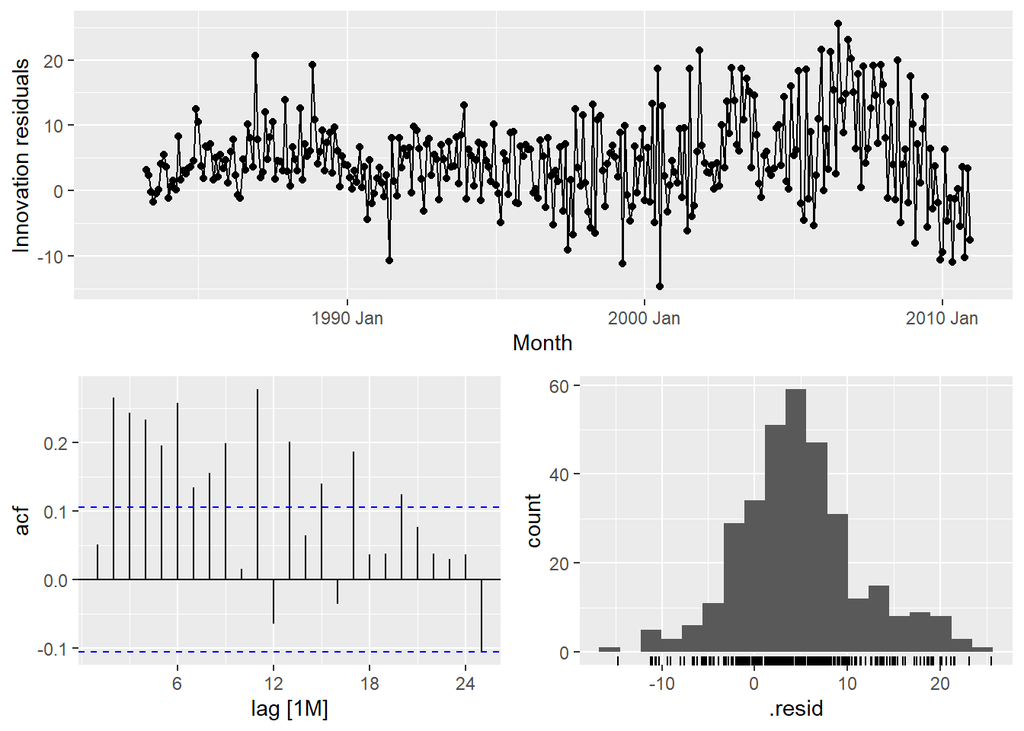

```r
fit %>% gg_tsresiduals()
```

```r
mean(augment(fit)$.innov , na.rm = TRUE)
```

```
## [1] 4.759459
```

```r
mean(augment(fit)$.innov , na.rm = TRUE) > median(augment(fit)$.innov , na.rm = TRUE)
```

```
## [1] TRUE
```

Do the residuals appear uncorrelated and normally distributed?

Although the innovation residuals and histogram appear to show homoskedasticity and normality, the ACF of the residuals display significant autocorrelation without an identifiable pattern. Additionally, the mean is greater than zero with a value of 4.76 meaning the forecasts are biased. Also, while the historgram distribution looks normal, it is slightly right skewed because the mean is greater than the median.

5. Produce the forecasts for the test data

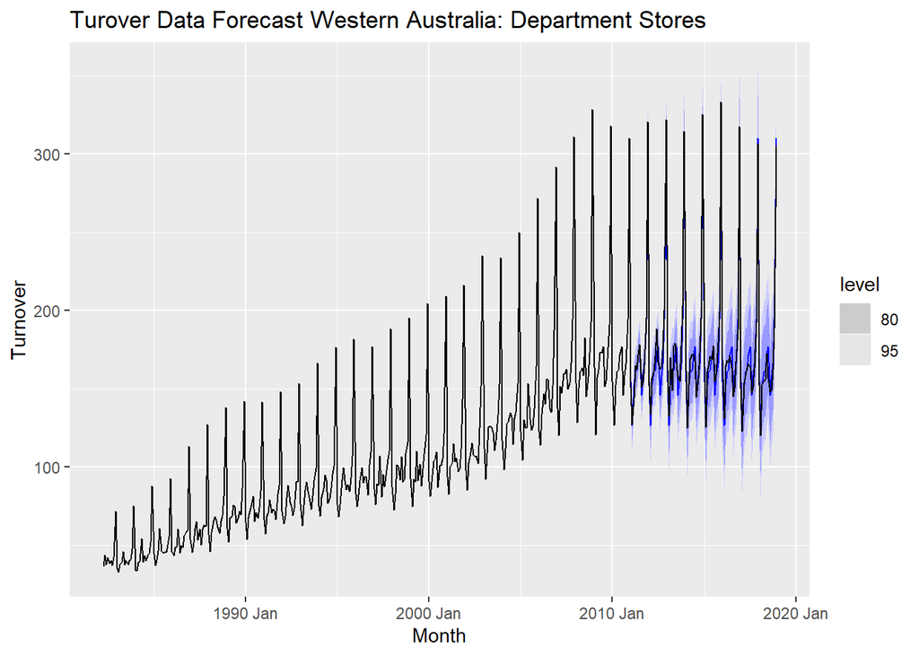

```r
fc <- fit %>%
  forecast(new_data = anti_join(myseries, myseries_train))
fc %>% autoplot(myseries) +
  labs(title="Turover Data Forecast Western Australia: Department Stores")
```

6. Compare the accuracy of your forecasts against the actual values.

```r
fit %>% accuracy()
```

```
## # A tibble: 1 x 12
##   State   Industry .model .type    ME  RMSE   MAE   MPE  MAPE  MASE RMSSE   ACF1
##   <chr>   <chr>    <chr>  <chr> <dbl> <dbl> <dbl> <dbl> <dbl> <dbl> <dbl>  <dbl>
## 1 Wester~ Departm~ SNAIV~ Trai~  4.76  8.10  6.26  4.82  6.25     1     1 0.0518
```

```r
fc %>% accuracy(myseries)
```

```
## # A tibble: 1 x 12
##   .model    State Industry .type    ME  RMSE   MAE   MPE  MAPE  MASE RMSSE  ACF1
##   <chr>     <chr> <chr>    <chr> <dbl> <dbl> <dbl> <dbl> <dbl> <dbl> <dbl> <dbl>
## 1 SNAIVE(T~ West~ Departm~ Test   1.73  7.97  6.24 0.746  3.57 0.996 0.983 0.107
```

Using the MAPE (mean absolute square error) we see that the Test data performed slightly better than the Training data. The Test data MAPE value of 3.57% means that the average difference between the forecasted value and the actual value is 3.57% whereas with our Training set, we have 6.25. [^3]

7. How sensitive are the accuracy measures to the amount of training data used?

The accuracy measures are quite sensitive to the amount of training data used. In our example, the training set had the quite a large amount of points and based on all (but the ACF1) measures it performed poorly in comparison to the test data which had fewer points. Having too many points leads to the possibility of introducing irrelevant data to forecasts, while not having enough data leads to under training and missing out on potential long term patterns needed for accurate forecasts.

## References

[^1]: https://faculty.fuqua.duke.edu/~rnau/Decision411_2007/411rand.htm
[^2]: https://otexts.com/fpp3/wn.html#fig:wnoise
[^3]: https://www.statology.org/what-is-a-good-mape/